# Graded Project - PDS 1

**Working with data using Python Libraries, Visualization, EDA & Data Preprocessing.**

**Context -**

A new football club named ‘GL United FC’ has just been inaugurated. This club does not have a team yet. The team is looking to hire players for their roster. Management wants to make such decisions using a data based approach. During a recent hiring drive, you were selected for the Data Science team as a data scientist. Your team has been tasked with creating a report which recommends players for the main team. To start with, a total of 15 players are required. Player data for all teams has been acquired from FIFA. This data contains information about the players, the clubs they are currently playing for and various performance measures. The team needs 20 possible players to choose from. You have been requested to do the analysis and formulate a report in order to help the management make a decision regarding potential players.

**Dataset Description -**

The data contains details for over 18,000 players playing in various football clubs in Europe. It contains information on age, skill rating, wages and player value, etc.

**Datasets -**

- fifa.csv – data file.
- fifa_ variable_information.csv - information on individual variables.

## Load and Explore Data

### 1. Import the required libraries and read the dataset.

```python
import numpy as np
import pandas as pd
import matplotlib.pyplot as plt
import seaborn as sns

import warnings
warnings.filterwarnings('ignore')
```

```python
data = pd.read_csv('fifa.csv')
```

```python
pd.set_option('display.max_columns', None)
pd.set_option('display.max_rows', None)
```

### 2. Check the first few samples, shape, info of the data and try to familiarize yourself with different features.

```python
data.head()
```

|  | ID | Name | Age | Photo | Nationality | Flag | Overall | Potential | Club | Club Logo | Value | Wage | Preferred Foot | International Reputation | Weak Foot | Skill Moves | Work Rate | Body Type | Position | Jersey Number | Joined | Loaned From | Contract Valid Until | Height | Weight | Crossing | Finishing | HeadingAccuracy | ShortPassing | … |
| --- | --- | --- | --- | --- | --- | --- | --- | --- | --- | --- | --- | --- | --- | --- | --- | --- | --- | --- | --- | --- | --- | --- | --- | --- | --- | --- | --- | --- | --- | --- |
| 0 | 158023 | L. Messi | 31 | https://cdn.sofifa.org/players/4/19/158023.png | Argentina | https://cdn.sofifa.org/flags/52.png | 94 | 94 | FC Barcelona | https://cdn.sofifa.org/teams/2/light/241.png | €110.5M | €565K | Left | 5.0 | 4.0 | 4.0 | Medium/ Medium | Messi | RF | 10.0 | Jul 1, 2004 | NaN | 2021 | 5'7 | 159lbs | 84.0 | 95.0 | 70.0 | 90.0 | … |
| 1 | 20801 | Cristiano Ronaldo | 33 | https://cdn.sofifa.org/players/4/19/20801.png | Portugal | https://cdn.sofifa.org/flags/38.png | 94 | 94 | Juventus | https://cdn.sofifa.org/teams/2/light/45.png | €77M | €405K | Right | 5.0 | 4.0 | 5.0 | High/ Low | C. Ronaldo | ST | 7.0 | Jul 10, 2018 | NaN | 2022 | 6'2 | 183lbs | 84.0 | 94.0 | 89.0 | 81.0 | … |
| 2 | 190871 | Neymar Jr | 26 | https://cdn.sofifa.org/players/4/19/190871.png | Brazil | https://cdn.sofifa.org/flags/54.png | 92 | 93 | Paris Saint-Germain | https://cdn.sofifa.org/teams/2/light/73.png | €118.5M | €290K | Right | 5.0 | 5.0 | 5.0 | High/ Medium | Neymar | LW | 10.0 | Aug 3, 2017 | NaN | 2022 | 5'9 | 150lbs | 79.0 | 87.0 | 62.0 | 84.0 | … |
| 3 | 193080 | De Gea | 27 | https://cdn.sofifa.org/players/4/19/193080.png | Spain | https://cdn.sofifa.org/flags/45.png | 91 | 93 | Manchester United | https://cdn.sofifa.org/teams/2/light/11.png | €72M | €260K | Right | 4.0 | 3.0 | 1.0 | Medium/ Medium | Lean | GK | 1.0 | Jul 1, 2011 | NaN | 2020 | 6'4 | 168lbs | 17.0 | 13.0 | 21.0 | 50.0 | … |
| 4 | 192985 | K. De Bruyne | 27 | https://cdn.sofifa.org/players/4/19/192985.png | Belgium | https://cdn.sofifa.org/flags/7.png | 91 | 92 | Manchester City | https://cdn.sofifa.org/teams/2/light/10.png | €102M | €355K | Right | 4.0 | 5.0 | 4.0 | High/ High | Normal | RCM | 7.0 | Aug 30, 2015 | NaN | 2023 | 5'11 | 154lbs | 93.0 | 82.0 | 55.0 | 92.0 | … |

```python
data.shape
```

```
(18207, 60)
```

```python
data.info()
```

```
<class 'pandas.core.frame.DataFrame'>
RangeIndex: 18207 entries, 0 to 18206
Data columns (total 60 columns):
 #   Column                    Non-Null Count  Dtype
---  ------                    --------------  -----
 0   ID                        18207 non-null  int64
 1   Name                      18207 non-null  object
 2   Age                       18207 non-null  int64
 3   Photo                     18207 non-null  object
 4   Nationality               18207 non-null  object
 5   Flag                      18207 non-null  object
 6   Overall                   18207 non-null  int64
 7   Potential                 18207 non-null  int64
 8   Club                      17966 non-null  object
 9   Club Logo                 18207 non-null  object
```

[output cut: 52 more lines]

### 3. Drop the columns which you think redundant for the analysis.

[Hint: columns like 'Photo','Flag','Club Logo']

```python
df = data.copy()

df.drop(['Photo', 'Flag', 'Club Logo'], axis=1, inplace=True)
df.head()
```

|  | ID | Name | Age | Nationality | Overall | Potential | Club | Value | Wage | Preferred Foot | International Reputation | Weak Foot | Skill Moves | Work Rate | Body Type | Position | Jersey Number | Joined | Loaned From | Contract Valid Until | Height | Weight | Crossing | Finishing | HeadingAccuracy | ShortPassing | Volleys | Dribbling | Curve | … |
| --- | --- | --- | --- | --- | --- | --- | --- | --- | --- | --- | --- | --- | --- | --- | --- | --- | --- | --- | --- | --- | --- | --- | --- | --- | --- | --- | --- | --- | --- | --- |
| 0 | 158023 | L. Messi | 31 | Argentina | 94 | 94 | FC Barcelona | €110.5M | €565K | Left | 5.0 | 4.0 | 4.0 | Medium/ Medium | Messi | RF | 10.0 | Jul 1, 2004 | NaN | 2021 | 5'7 | 159lbs | 84.0 | 95.0 | 70.0 | 90.0 | 86.0 | 97.0 | 93.0 | … |
| 1 | 20801 | Cristiano Ronaldo | 33 | Portugal | 94 | 94 | Juventus | €77M | €405K | Right | 5.0 | 4.0 | 5.0 | High/ Low | C. Ronaldo | ST | 7.0 | Jul 10, 2018 | NaN | 2022 | 6'2 | 183lbs | 84.0 | 94.0 | 89.0 | 81.0 | 87.0 | 88.0 | 81.0 | … |
| 2 | 190871 | Neymar Jr | 26 | Brazil | 92 | 93 | Paris Saint-Germain | €118.5M | €290K | Right | 5.0 | 5.0 | 5.0 | High/ Medium | Neymar | LW | 10.0 | Aug 3, 2017 | NaN | 2022 | 5'9 | 150lbs | 79.0 | 87.0 | 62.0 | 84.0 | 84.0 | 96.0 | 88.0 | … |
| 3 | 193080 | De Gea | 27 | Spain | 91 | 93 | Manchester United | €72M | €260K | Right | 4.0 | 3.0 | 1.0 | Medium/ Medium | Lean | GK | 1.0 | Jul 1, 2011 | NaN | 2020 | 6'4 | 168lbs | 17.0 | 13.0 | 21.0 | 50.0 | 13.0 | 18.0 | 21.0 | … |
| 4 | 192985 | K. De Bruyne | 27 | Belgium | 91 | 92 | Manchester City | €102M | €355K | Right | 4.0 | 5.0 | 4.0 | High/ High | Normal | RCM | 7.0 | Aug 30, 2015 | NaN | 2023 | 5'11 | 154lbs | 93.0 | 82.0 | 55.0 | 92.0 | 82.0 | 86.0 | 85.0 | … |

```python
df.columns
```

```
Index(['ID', 'Name', 'Age', 'Nationality', 'Overall', 'Potential', 'Club',
       'Value', 'Wage', 'Preferred Foot', 'International Reputation',
       'Weak Foot', 'Skill Moves', 'Work Rate', 'Body Type', 'Position',
       'Jersey Number', 'Joined', 'Loaned From', 'Contract Valid Until',
       'Height', 'Weight', 'Crossing', 'Finishing', 'HeadingAccuracy',
       'ShortPassing', 'Volleys', 'Dribbling', 'Curve', 'FKAccuracy',
       'LongPassing', 'BallControl', 'Acceleration', 'SprintSpeed', 'Agility',
       'Reactions', 'Balance', 'ShotPower', 'Jumping', 'Stamina', 'Strength',
       'LongShots', 'Aggression', 'Interceptions', 'Positioning', 'Vision',
       'Penalties', 'Composure', 'Marking', 'StandingTackle', 'SlidingTackle',
       'GKDiving', 'GKHandling', 'GKKicking', 'GKPositioning', 'GKReflexes',
       'Release Clause'],
      dtype='object')
```

## Data Cleaning and Preprocessing

### 4. Convert the columns "Value", "Wage", "Release Clause" to float datatype after getting rid of currency symbol and suffix.

- Note: When the record/entry has "M"(indicates millions) as suffix you need to multiply that value with 1000000
- When the record/entry has "K"(indicates thousands) as suffix you need to multiply that value with 1000

```python
cols = ['Value', 'Wage', 'Release Clause']
df[cols] = df[cols].replace({'€': '', 'M': 'e+06', 'K': 'e+03'}, regex=True).astype(float)
df.head()
```

|  | ID | Name | Age | Nationality | Overall | Potential | Club | Value | Wage | Preferred Foot | International Reputation | Weak Foot | Skill Moves | Work Rate | Body Type | Position | Jersey Number | Joined | Loaned From | Contract Valid Until | Height | Weight | Crossing | Finishing | HeadingAccuracy | ShortPassing | Volleys | Dribbling | Curve | … |
| --- | --- | --- | --- | --- | --- | --- | --- | --- | --- | --- | --- | --- | --- | --- | --- | --- | --- | --- | --- | --- | --- | --- | --- | --- | --- | --- | --- | --- | --- | --- |
| 0 | 158023 | L. Messi | 31 | Argentina | 94 | 94 | FC Barcelona | 110500000.0 | 565000.0 | Left | 5.0 | 4.0 | 4.0 | Medium/ Medium | Messi | RF | 10.0 | Jul 1, 2004 | NaN | 2021 | 5'7 | 159lbs | 84.0 | 95.0 | 70.0 | 90.0 | 86.0 | 97.0 | 93.0 | … |
| 1 | 20801 | Cristiano Ronaldo | 33 | Portugal | 94 | 94 | Juventus | 77000000.0 | 405000.0 | Right | 5.0 | 4.0 | 5.0 | High/ Low | C. Ronaldo | ST | 7.0 | Jul 10, 2018 | NaN | 2022 | 6'2 | 183lbs | 84.0 | 94.0 | 89.0 | 81.0 | 87.0 | 88.0 | 81.0 | … |
| 2 | 190871 | Neymar Jr | 26 | Brazil | 92 | 93 | Paris Saint-Germain | 118500000.0 | 290000.0 | Right | 5.0 | 5.0 | 5.0 | High/ Medium | Neymar | LW | 10.0 | Aug 3, 2017 | NaN | 2022 | 5'9 | 150lbs | 79.0 | 87.0 | 62.0 | 84.0 | 84.0 | 96.0 | 88.0 | … |
| 3 | 193080 | De Gea | 27 | Spain | 91 | 93 | Manchester United | 72000000.0 | 260000.0 | Right | 4.0 | 3.0 | 1.0 | Medium/ Medium | Lean | GK | 1.0 | Jul 1, 2011 | NaN | 2020 | 6'4 | 168lbs | 17.0 | 13.0 | 21.0 | 50.0 | 13.0 | 18.0 | 21.0 | … |
| 4 | 192985 | K. De Bruyne | 27 | Belgium | 91 | 92 | Manchester City | 102000000.0 | 355000.0 | Right | 4.0 | 5.0 | 4.0 | High/ High | Normal | RCM | 7.0 | Aug 30, 2015 | NaN | 2023 | 5'11 | 154lbs | 93.0 | 82.0 | 55.0 | 92.0 | 82.0 | 86.0 | 85.0 | … |

### 5. Convert the column "Joined" into integer data type with keeping only the year.

```python
df['Joined'].head()
```

```
0     Jul 1, 2004
1    Jul 10, 2018
2     Aug 3, 2017
3     Jul 1, 2011
4    Aug 30, 2015
Name: Joined, dtype: object
```

```python
df['Joined'] = pd.to_datetime(df['Joined']).dt.year.astype('Int64')
print('Datatype - ', df['Joined'].dtype)
df[['Name','Joined']].head()
```

```
Datatype -  Int64
```

|  | Name | Joined |
| --- | --- | --- |
| 0 | L. Messi | 2004 |
| 1 | Cristiano Ronaldo | 2018 |
| 2 | Neymar Jr | 2017 |
| 3 | De Gea | 2011 |
| 4 | K. De Bruyne | 2015 |

### 6. Convert the column "Contract Valid Until" to pandas datetime type.

```python
df['Contract Valid Until'].head()
```

```
0    2021
1    2022
2    2022
3    2020
4    2023
Name: Contract Valid Until, dtype: object
```

```python
df['Contract Valid Until'] = pd.to_datetime(df['Contract Valid Until'], format='mixed')
df[['Name','Contract Valid Until']].head()
```

|  | Name | Contract Valid Until |
| --- | --- | --- |
| 0 | L. Messi | 2021-01-01 |
| 1 | Cristiano Ronaldo | 2022-01-01 |
| 2 | Neymar Jr | 2022-01-01 |
| 3 | De Gea | 2020-01-01 |
| 4 | K. De Bruyne | 2023-01-01 |

### 7. The column "Height" is in inches with a quotation mark, Convert to float with decimal points.

```python
df['Height'].head()
```

```
0     5'7
1     6'2
2     5'9
3     6'4
4    5'11
Name: Height, dtype: object
```

```python
df['Height'] = df['Height'].str.replace('\'','-')
```

```python
df['Height'].head()
```

```
0     5-7
1     6-2
2     5-9
3     6-4
4    5-11
Name: Height, dtype: object
```

```python
feet = df['Height'].str.split('-', n=1).str[0].astype(float)
inches = df['Height'].str.split('-', n=1).str[1].astype(float)

df['Height'] = (feet+(inches/12)).round(decimals=2)
df[['Name', 'Height']].head()
```

|  | Name | Height |
| --- | --- | --- |
| 0 | L. Messi | 5.58 |
| 1 | Cristiano Ronaldo | 6.17 |
| 2 | Neymar Jr | 5.75 |
| 3 | De Gea | 6.33 |
| 4 | K. De Bruyne | 5.92 |

### 8. The column "Weight" has the suffix as lbs, remove the suffix and convert to float.

```python
df['Weight'].head()
```

```
0    159lbs
1    183lbs
2    150lbs
3    168lbs
4    154lbs
Name: Weight, dtype: object
```

```python
df['Weight'] = df['Weight'].str.removesuffix('lbs').astype(float)
print('Datatype - ', df['Weight'].dtype)
df[['Name', 'Weight']].head()
```

```
Datatype -  float64
```

|  | Name | Weight |
| --- | --- | --- |
| 0 | L. Messi | 159.0 |
| 1 | Cristiano Ronaldo | 183.0 |
| 2 | Neymar Jr | 150.0 |
| 3 | De Gea | 168.0 |
| 4 | K. De Bruyne | 154.0 |

### 9. Check for the percentage of missing values and impute them with appropriate imputation techniques.

Finding the Missing/Null Values -

```python
missing_value = (df.isnull().sum() * 100 / len(df)).round(2)
df_missing_value = pd.DataFrame(missing_value)
df_missing_value
```

|  | 0 |
| --- | --- |
| ID | 0.00 |
| Name | 0.00 |
| Age | 0.00 |
| Nationality | 0.00 |
| Overall | 0.00 |
| Potential | 0.00 |
| Club | 1.32 |
| Value | 0.00 |
| Wage | 0.00 |
| Preferred Foot | 0.26 |
| International Reputation | 0.26 |
| Weak Foot | 0.26 |
| Skill Moves | 0.26 |
| Work Rate | 0.26 |
| Body Type | 0.26 |
| Position | 0.33 |
| Jersey Number | 0.33 |
| Joined | 8.53 |
| Loaned From | 93.06 |
| Contract Valid Until | 1.59 |
| Height | 0.26 |
| Weight | 0.26 |
| Crossing | 0.26 |
| Finishing | 0.26 |
| HeadingAccuracy | 0.26 |
| ShortPassing | 0.26 |
| Volleys | 0.26 |
| Dribbling | 0.26 |
| Curve | 0.26 |
| FKAccuracy | 0.26 |
| LongPassing | 0.26 |
| BallControl | 0.26 |
| Acceleration | 0.26 |
| SprintSpeed | 0.26 |
| Agility | 0.26 |
| Reactions | 0.26 |
| Balance | 0.26 |
| ShotPower | 0.26 |
| Jumping | 0.26 |
| Stamina | 0.26 |
| Strength | 0.26 |
| LongShots | 0.26 |
| Aggression | 0.26 |
| Interceptions | 0.26 |
| Positioning | 0.26 |
| Vision | 0.26 |
| Penalties | 0.26 |
| Composure | 0.26 |
| Marking | 0.26 |
| StandingTackle | 0.26 |
| SlidingTackle | 0.26 |
| GKDiving | 0.26 |
| GKHandling | 0.26 |
| GKKicking | 0.26 |
| GKPositioning | 0.26 |
| GKReflexes | 0.26 |
| Release Clause | 8.59 |

- From the above we infer that the column "Loaned From" is having missing values which is greater than 90%.
- Therefore, we drop the column "Loaned From" in the dataset.

```python
df.drop('Loaned From', axis=1, inplace=True)
print('Column "Loaned From" is dropped.')
```

```
Column "Loaned From" is dropped.
```

**Columns with Missing Numerical Values -**

```python
missing_data = df.isnull().sum()/len(df)
data_index = [i  for i in missing_data[missing_data>0].index]

numerical = [i for i in data_index
           if i in df.columns and  df[i].dtype!=object]
df_numerical = pd.DataFrame(numerical)
df_numerical
```

|  | 0 |
| --- | --- |
| 0 | International Reputation |
| 1 | Weak Foot |
| 2 | Skill Moves |
| 3 | Jersey Number |
| 4 | Joined |
| 5 | Contract Valid Until |
| 6 | Height |
| 7 | Weight |
| 8 | Crossing |
| 9 | Finishing |
| 10 | HeadingAccuracy |
| 11 | ShortPassing |
| 12 | Volleys |
| 13 | Dribbling |
| 14 | Curve |
| 15 | FKAccuracy |
| 16 | LongPassing |
| 17 | BallControl |
| 18 | Acceleration |
| 19 | SprintSpeed |
| 20 | Agility |
| 21 | Reactions |
| 22 | Balance |
| 23 | ShotPower |
| 24 | Jumping |
| 25 | Stamina |
| 26 | Strength |
| 27 | LongShots |
| 28 | Aggression |
| 29 | Interceptions |
| 30 | Positioning |
| 31 | Vision |
| 32 | Penalties |
| 33 | Composure |
| 34 | Marking |
| 35 | StandingTackle |
| 36 | SlidingTackle |
| 37 | GKDiving |
| 38 | GKHandling |
| 39 | GKKicking |
| 40 | GKPositioning |
| 41 | GKReflexes |
| 42 | Release Clause |

**Replacing Missing Numerical Values with the Median Value.**

```python
for j in numerical:
    df[j]=df[j].fillna(df[j].median())

print('Missing Numerical Values Replaced with the Median')
```

```
Missing Numerical Values Replaced with the Median
```

**Columns with Missing Categorical Values -**

```python
categorical = [i for i in data_index
           if i in df.columns and  df[i].dtype==object]
df_categorical = pd.DataFrame(categorical)
df_categorical
```

|  | 0 |
| --- | --- |
| 0 | Club |
| 1 | Preferred Foot |
| 2 | Work Rate |
| 3 | Body Type |
| 4 | Position |

**Replacing Missing Categorical Values with Mode.**

```python
for j in categorical:
    df[j]=df[j].fillna(df[j].mode()[0])

print('Missing Categorical Values Replaced with Mode')
```

```
Missing Categorical Values Replaced with Mode
```

**Re-Checking for Missing Value.**

```python
missing_data1 = df.isnull().sum()
df_missing_data1 = pd.DataFrame(missing_data1)
df_missing_data1.reset_index()
```

|  | index | 0 |
| --- | --- | --- |
| 0 | ID | 0 |
| 1 | Name | 0 |
| 2 | Age | 0 |
| 3 | Nationality | 0 |
| 4 | Overall | 0 |
| 5 | Potential | 0 |
| 6 | Club | 0 |
| 7 | Value | 0 |
| 8 | Wage | 0 |
| 9 | Preferred Foot | 0 |
| 10 | International Reputation | 0 |
| 11 | Weak Foot | 0 |
| 12 | Skill Moves | 0 |
| 13 | Work Rate | 0 |
| 14 | Body Type | 0 |
| 15 | Position | 0 |
| 16 | Jersey Number | 0 |
| 17 | Joined | 0 |
| 18 | Contract Valid Until | 0 |
| 19 | Height | 0 |
| 20 | Weight | 0 |
| 21 | Crossing | 0 |
| 22 | Finishing | 0 |
| 23 | HeadingAccuracy | 0 |
| 24 | ShortPassing | 0 |
| 25 | Volleys | 0 |
| 26 | Dribbling | 0 |
| 27 | Curve | 0 |
| 28 | FKAccuracy | 0 |
| 29 | LongPassing | 0 |
| 30 | BallControl | 0 |
| 31 | Acceleration | 0 |
| 32 | SprintSpeed | 0 |
| 33 | Agility | 0 |
| 34 | Reactions | 0 |
| 35 | Balance | 0 |
| 36 | ShotPower | 0 |
| 37 | Jumping | 0 |
| 38 | Stamina | 0 |
| 39 | Strength | 0 |
| 40 | LongShots | 0 |
| 41 | Aggression | 0 |
| 42 | Interceptions | 0 |
| 43 | Positioning | 0 |
| 44 | Vision | 0 |
| 45 | Penalties | 0 |
| 46 | Composure | 0 |
| 47 | Marking | 0 |
| 48 | StandingTackle | 0 |
| 49 | SlidingTackle | 0 |
| 50 | GKDiving | 0 |
| 51 | GKHandling | 0 |
| 52 | GKKicking | 0 |
| 53 | GKPositioning | 0 |
| 54 | GKReflexes | 0 |
| 55 | Release Clause | 0 |

## Exploratory Data Analysis

### 10. Plot the distribution of Overall rating for all the players and write your findings.

```python
df['Overall'].head()
```

```
0    94
1    94
2    92
3    91
4    91
Name: Overall, dtype: int64
```

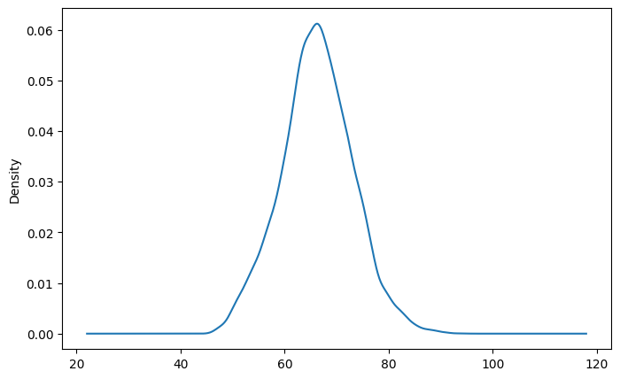

```python
plt.figure(figsize=(8,5))
df['Overall'].plot(kind='kde')
plt.show()
```

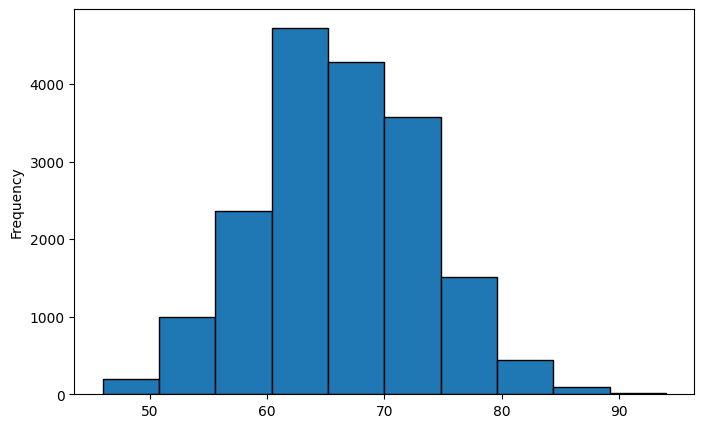

```python
plt.figure(figsize=(8,5))
df['Overall'].plot(kind='hist', edgecolor='black')
plt.show()
```

- From the above distributions we infer that the Overall Rating of the Players Ranges between [50-90].
- Maximum frequency range lies between [60-70].

### 11. Retrieve the "Names" of Top 20 players based on the "Overall" Rating.

```python
top_20_list = df.groupby('Name')['Overall'].max().sort_values(ascending=False).head(20)
dataframe = pd.DataFrame(top_20_list)
dataframe.reset_index()
```

|  | Name | Overall |
| --- | --- | --- |
| 0 | Cristiano Ronaldo | 94 |
| 1 | L. Messi | 94 |
| 2 | Neymar Jr | 92 |
| 3 | Sergio Ramos | 91 |
| 4 | E. Hazard | 91 |
| 5 | De Gea | 91 |
| 6 | L. Suárez | 91 |
| 7 | L. Modrić | 91 |
| 8 | K. De Bruyne | 91 |
| 9 | D. Godín | 90 |
| 10 | David Silva | 90 |
| 11 | T. Kroos | 90 |
| 12 | J. Oblak | 90 |
| 13 | R. Lewandowski | 90 |
| 14 | H. Kane | 89 |
| 15 | T. Courtois | 89 |
| 16 | S. Agüero | 89 |
| 17 | M. ter Stegen | 89 |
| 18 | Sergio Busquets | 89 |
| 19 | E. Cavani | 89 |

### 12. Generate a dataframe which should include all the information of the Top 20 players based on the Overall rating.

```python
df_list = df[(df['Name'].isin(top_20_list.index)) & (df['Overall'].isin(top_20_list.values))]
df_list.reset_index()
```

|  | index | ID | Name | Age | Nationality | Overall | Potential | Club | Value | Wage | Preferred Foot | International Reputation | Weak Foot | Skill Moves | Work Rate | Body Type | Position | Jersey Number | Joined | Contract Valid Until | Height | Weight | Crossing | Finishing | HeadingAccuracy | ShortPassing | Volleys | Dribbling | Curve | … |
| --- | --- | --- | --- | --- | --- | --- | --- | --- | --- | --- | --- | --- | --- | --- | --- | --- | --- | --- | --- | --- | --- | --- | --- | --- | --- | --- | --- | --- | --- | --- |
| 0 | 0 | 158023 | L. Messi | 31 | Argentina | 94 | 94 | FC Barcelona | 110500000.0 | 565000.0 | Left | 5.0 | 4.0 | 4.0 | Medium/ Medium | Messi | RF | 10.0 | 2004 | 2021-01-01 | 5.58 | 159.0 | 84.0 | 95.0 | 70.0 | 90.0 | 86.0 | 97.0 | 93.0 | … |
| 1 | 1 | 20801 | Cristiano Ronaldo | 33 | Portugal | 94 | 94 | Juventus | 77000000.0 | 405000.0 | Right | 5.0 | 4.0 | 5.0 | High/ Low | C. Ronaldo | ST | 7.0 | 2018 | 2022-01-01 | 6.17 | 183.0 | 84.0 | 94.0 | 89.0 | 81.0 | 87.0 | 88.0 | 81.0 | … |
| 2 | 2 | 190871 | Neymar Jr | 26 | Brazil | 92 | 93 | Paris Saint-Germain | 118500000.0 | 290000.0 | Right | 5.0 | 5.0 | 5.0 | High/ Medium | Neymar | LW | 10.0 | 2017 | 2022-01-01 | 5.75 | 150.0 | 79.0 | 87.0 | 62.0 | 84.0 | 84.0 | 96.0 | 88.0 | … |
| 3 | 3 | 193080 | De Gea | 27 | Spain | 91 | 93 | Manchester United | 72000000.0 | 260000.0 | Right | 4.0 | 3.0 | 1.0 | Medium/ Medium | Lean | GK | 1.0 | 2011 | 2020-01-01 | 6.33 | 168.0 | 17.0 | 13.0 | 21.0 | 50.0 | 13.0 | 18.0 | 21.0 | … |
| 4 | 4 | 192985 | K. De Bruyne | 27 | Belgium | 91 | 92 | Manchester City | 102000000.0 | 355000.0 | Right | 4.0 | 5.0 | 4.0 | High/ High | Normal | RCM | 7.0 | 2015 | 2023-01-01 | 5.92 | 154.0 | 93.0 | 82.0 | 55.0 | 92.0 | 82.0 | 86.0 | 85.0 | … |
| 5 | 5 | 183277 | E. Hazard | 27 | Belgium | 91 | 91 | Chelsea | 93000000.0 | 340000.0 | Right | 4.0 | 4.0 | 4.0 | High/ Medium | Normal | LF | 10.0 | 2012 | 2020-01-01 | 5.67 | 163.0 | 81.0 | 84.0 | 61.0 | 89.0 | 80.0 | 95.0 | 83.0 | … |
| 6 | 6 | 177003 | L. Modrić | 32 | Croatia | 91 | 91 | Real Madrid | 67000000.0 | 420000.0 | Right | 4.0 | 4.0 | 4.0 | High/ High | Lean | RCM | 10.0 | 2012 | 2020-01-01 | 5.67 | 146.0 | 86.0 | 72.0 | 55.0 | 93.0 | 76.0 | 90.0 | 85.0 | … |
| 7 | 7 | 176580 | L. Suárez | 31 | Uruguay | 91 | 91 | FC Barcelona | 80000000.0 | 455000.0 | Right | 5.0 | 4.0 | 3.0 | High/ Medium | Normal | RS | 9.0 | 2014 | 2021-01-01 | 6.00 | 190.0 | 77.0 | 93.0 | 77.0 | 82.0 | 88.0 | 87.0 | 86.0 | … |
| 8 | 8 | 155862 | Sergio Ramos | 32 | Spain | 91 | 91 | Real Madrid | 51000000.0 | 380000.0 | Right | 4.0 | 3.0 | 3.0 | High/ Medium | Normal | RCB | 15.0 | 2005 | 2020-01-01 | 6.00 | 181.0 | 66.0 | 60.0 | 91.0 | 78.0 | 66.0 | 63.0 | 74.0 | … |
| 9 | 9 | 200389 | J. Oblak | 25 | Slovenia | 90 | 93 | Atlético Madrid | 68000000.0 | 94000.0 | Right | 3.0 | 3.0 | 1.0 | Medium/ Medium | Normal | GK | 1.0 | 2014 | 2021-01-01 | 6.17 | 192.0 | 13.0 | 11.0 | 15.0 | 29.0 | 13.0 | 12.0 | 13.0 | … |
| 10 | 10 | 188545 | R. Lewandowski | 29 | Poland | 90 | 90 | FC Bayern München | 77000000.0 | 205000.0 | Right | 4.0 | 4.0 | 4.0 | High/ Medium | Normal | ST | 9.0 | 2014 | 2021-01-01 | 6.00 | 176.0 | 62.0 | 91.0 | 85.0 | 83.0 | 89.0 | 85.0 | 77.0 | … |
| 11 | 11 | 182521 | T. Kroos | 28 | Germany | 90 | 90 | Real Madrid | 76500000.0 | 355000.0 | Right | 4.0 | 5.0 | 3.0 | Medium/ Medium | Normal | LCM | 8.0 | 2014 | 2022-01-01 | 6.00 | 168.0 | 88.0 | 76.0 | 54.0 | 92.0 | 82.0 | 81.0 | 86.0 | … |
| 12 | 12 | 182493 | D. Godín | 32 | Uruguay | 90 | 90 | Atlético Madrid | 44000000.0 | 125000.0 | Right | 3.0 | 3.0 | 2.0 | Medium/ High | Lean | CB | 10.0 | 2010 | 2019-01-01 | 6.17 | 172.0 | 55.0 | 42.0 | 92.0 | 79.0 | 47.0 | 53.0 | 49.0 | … |
| 13 | 13 | 168542 | David Silva | 32 | Spain | 90 | 90 | Manchester City | 60000000.0 | 285000.0 | Left | 4.0 | 2.0 | 4.0 | High/ Medium | Normal | LCM | 21.0 | 2010 | 2020-01-01 | 5.67 | 148.0 | 84.0 | 76.0 | 54.0 | 93.0 | 82.0 | 89.0 | 82.0 | … |
| 14 | 16 | 202126 | H. Kane | 24 | England | 89 | 91 | Tottenham Hotspur | 83500000.0 | 205000.0 | Right | 3.0 | 4.0 | 3.0 | High/ High | Normal | ST | 9.0 | 2010 | 2024-01-01 | 6.17 | 196.0 | 75.0 | 94.0 | 85.0 | 80.0 | 84.0 | 80.0 | 78.0 | … |
| 15 | 18 | 192448 | M. ter Stegen | 26 | Germany | 89 | 92 | FC Barcelona | 58000000.0 | 240000.0 | Right | 3.0 | 4.0 | 1.0 | Medium/ Medium | Normal | GK | 22.0 | 2014 | 2022-01-01 | 6.17 | 187.0 | 15.0 | 14.0 | 11.0 | 36.0 | 14.0 | 17.0 | 18.0 | … |
| 16 | 19 | 192119 | T. Courtois | 26 | Belgium | 89 | 90 | Real Madrid | 53500000.0 | 240000.0 | Left | 4.0 | 2.0 | 1.0 | Medium/ Medium | Courtois | GK | 1.0 | 2018 | 2024-01-01 | 6.50 | 212.0 | 14.0 | 14.0 | 13.0 | 33.0 | 12.0 | 13.0 | 19.0 | … |
| 17 | 20 | 189511 | Sergio Busquets | 29 | Spain | 89 | 89 | FC Barcelona | 51500000.0 | 315000.0 | Right | 4.0 | 3.0 | 3.0 | Medium/ Medium | Lean | CDM | 5.0 | 2008 | 2023-01-01 | 6.17 | 168.0 | 62.0 | 67.0 | 68.0 | 89.0 | 44.0 | 80.0 | 66.0 | … |
| 18 | 21 | 179813 | E. Cavani | 31 | Uruguay | 89 | 89 | Paris Saint-Germain | 60000000.0 | 200000.0 | Right | 4.0 | 4.0 | 3.0 | High/ High | Lean | LS | 21.0 | 2013 | 2020-01-01 | 6.08 | 170.0 | 70.0 | 89.0 | 89.0 | 78.0 | 90.0 | 80.0 | 77.0 | … |
| 19 | 23 | 153079 | S. Agüero | 30 | Argentina | 89 | 89 | Manchester City | 64500000.0 | 300000.0 | Right | 4.0 | 4.0 | 4.0 | High/ Medium | Stocky | ST | 10.0 | 2011 | 2021-01-01 | 5.67 | 154.0 | 70.0 | 93.0 | 77.0 | 81.0 | 85.0 | 89.0 | 82.0 | … |

### 13. What is the average "Age" and "Wage" of these top 20 players?

(Use the data frame created in the Question 11)

```python
avg = df_list[['Age', 'Wage']].mean()
df_avg = pd.DataFrame(avg)
df_avg.T
```

|  | Age | Wage |
| --- | --- | --- |
| 0 | 28.9 | 301700.0 |

### 14. Among the top 20 players based on the Overall rating, which player has the highest wage? Display the name of the player with his wage.

```python
df_maxwage = df_list[['Wage']].idxmax()
df.loc[df_maxwage, ['Name', 'Wage']]
```

|  | Name | Wage |
| --- | --- | --- |
| 0 | L. Messi | 565000.0 |

### 15. Generate a dataframe which should include the "Player Name", "Club Name", "Wage", and "Overall Rating".

i) Find the average Overall rating for each club.  
ii) Display the average overall rating of Top10 Clubs using a plot

```python
df_list1 = df.loc[:, ['Name', 'Club', 'Wage', 'Overall']]
df_list1.head()
```

|  | Name | Club | Wage | Overall |
| --- | --- | --- | --- | --- |
| 0 | L. Messi | FC Barcelona | 565000.0 | 94 |
| 1 | Cristiano Ronaldo | Juventus | 405000.0 | 94 |
| 2 | Neymar Jr | Paris Saint-Germain | 290000.0 | 92 |
| 3 | De Gea | Manchester United | 260000.0 | 91 |
| 4 | K. De Bruyne | Manchester City | 355000.0 | 91 |

**Average Overall Rating for Each Club -**

```python
rating = df_list1.groupby('Club')['Overall'].mean().sort_values(ascending=False)
df_rating = pd.DataFrame(rating)
df_rating.reset_index()
```

|  | Club | Overall |
| --- | --- | --- |
| 0 | Juventus | 82.280000 |
| 1 | Napoli | 80.000000 |
| 2 | Inter | 79.750000 |
| 3 | Real Madrid | 78.242424 |
| 4 | Milan | 78.074074 |
| 5 | FC Barcelona | 78.030303 |
| 6 | Paris Saint-Germain | 77.433333 |
| 7 | Roma | 77.423077 |
| 8 | Manchester United | 77.242424 |
| 9 | SL Benfica | 77.000000 |
| 10 | FC Bayern München | 77.000000 |
| 11 | Chelsea | 76.787879 |
| 12 | Manchester City | 76.727273 |
| 13 | Tottenham Hotspur | 76.696970 |
| 14 | FC Porto | 76.678571 |
| 15 | Sporting CP | 76.133333 |
| 16 | Liverpool | 76.000000 |
| 17 | Bayer 04 Leverkusen | 75.807692 |
| 18 | Lazio | 75.437500 |
| 19 | Borussia Dortmund | 75.333333 |
| 20 | Sevilla FC | 75.200000 |
| 21 | Real Betis | 75.185185 |
| 22 | Arsenal | 75.181818 |
| 23 | Atlético Madrid | 75.060606 |
| 24 | SC Braga | 74.821429 |
| 25 | Valencia CF | 74.696970 |
| 26 | Villarreal CF | 74.343750 |
| 27 | FC Schalke 04 | 74.310345 |
| 28 | Everton | 74.121212 |
| 29 | Leicester City | 73.843750 |

[output cut: 621 more lines]

**Average Overall Rating of the Top 10 Clubs using Barplot -**

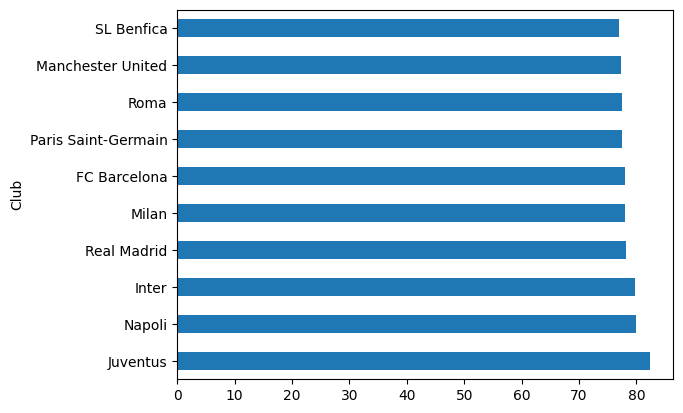

```python
club_rating = rating.head(10)
club_rating.plot(kind='barh')
plt.show()
```

### 16. What is the relationship between age and individual potential of the player? Visualize the relationship with appropriate plot and Comment on the same.

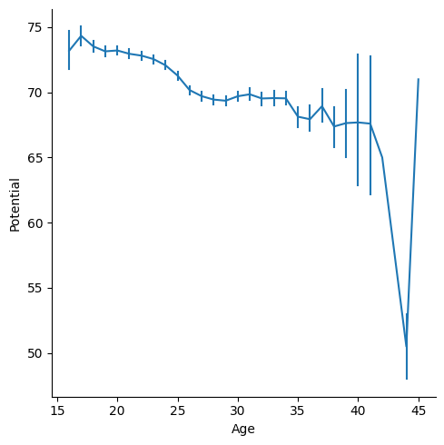

```python
sns.relplot(x='Age', y='Potential', data=df, kind='line', errorbar='ci', err_style='bars')
plt.show()
```

- From the above we infer that the "Highest Potential" of the Players is between Ages of 16 to 22 and after which it decreases gradually till the Age of 40.
- After the Age of 40 there is a steep decline in the "Player’s Potential".
- We can also derive that the relationship between the "Players Age" and the "Player’s Potential" is Inversely Proportional.

### 17. Which features directly contribute to the wages of the players? Support your answer with a plot and a metric.

- Use Potential, Overall, Value, International Reputation, and Release Clause)

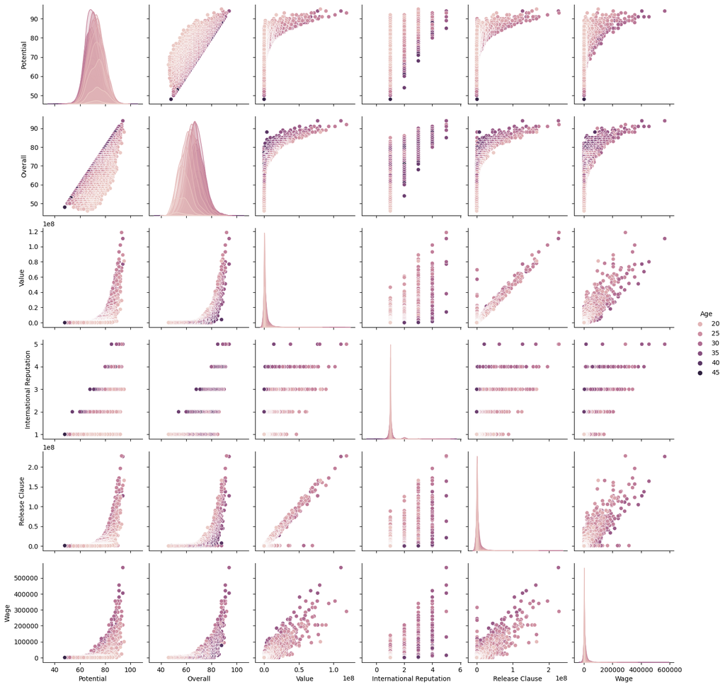

```python
sns.pairplot(df[['Potential', 'Overall', 'Value', 'International Reputation', 'Release Clause', 'Wage', 'Age']], hue='Age')
plt.show()
```

```python
df[['Potential', 'Overall', 'Value', 'International Reputation', 'Release Clause', 'Wage', 'Age']].cov()
```

|  | Potential | Overall | Value | International Reputation | Release Clause | Wage | Age |
| --- | --- | --- | --- | --- | --- | --- | --- |
| Potential | 3.765658e+01 | 2.802156e+01 | 1.978346e+07 | 9.005379e-01 | 3.615364e+07 | 6.566507e+04 | -7.259186e+00 |
| Overall | 2.802156e+01 | 4.773331e+01 | 2.423998e+07 | 1.358576e+00 | 4.366496e+07 | 8.692792e+04 | 1.459474e+01 |
| Value | 1.978346e+07 | 2.423998e+07 | 3.130327e+13 | 1.438433e+06 | 5.791542e+13 | 1.056609e+11 | 1.960181e+06 |
| International Reputation | 9.005379e-01 | 1.358576e+00 | 1.438433e+06 | 1.548846e-01 | 2.603235e+06 | 5.789708e+03 | 4.658214e-01 |
| Release Clause | 3.615364e+07 | 4.366496e+07 | 5.791542e+13 | 2.603235e+06 | 1.139595e+14 | 1.933141e+11 | 3.244062e+06 |
| Wage | 6.566507e+04 | 8.692792e+04 | 1.056609e+11 | 5.789708e+03 | 1.933141e+11 | 4.839688e+08 | 1.450059e+04 |
| Age | -7.259186e+00 | 1.459474e+01 | 1.960181e+06 | 4.658214e-01 | 3.244062e+06 | 1.450059e+04 | 2.180836e+01 |

```python
data_corr = df[['Potential', 'Overall', 'Value', 'International Reputation', 'Release Clause', 'Wage', 'Age']].corr()
data_corr
```

|  | Potential | Overall | Value | International Reputation | Release Clause | Wage | Age |
| --- | --- | --- | --- | --- | --- | --- | --- |
| Potential | 1.000000 | 0.660939 | 0.576218 | 0.372887 | 0.551895 | 0.486413 | -0.253312 |
| Overall | 0.660939 | 1.000000 | 0.627085 | 0.499654 | 0.592035 | 0.571926 | 0.452350 |
| Value | 0.576218 | 0.627085 | 1.000000 | 0.653267 | 0.969670 | 0.858442 | 0.075022 |
| International Reputation | 0.372887 | 0.499654 | 0.653267 | 1.000000 | 0.619632 | 0.668719 | 0.253457 |
| Release Clause | 0.551895 | 0.592035 | 0.969670 | 0.619632 | 1.000000 | 0.823151 | 0.065073 |
| Wage | 0.486413 | 0.571926 | 0.858442 | 0.668719 | 0.823151 | 1.000000 | 0.141145 |
| Age | -0.253312 | 0.452350 | 0.075022 | 0.253457 | 0.065073 | 0.141145 | 1.000000 |

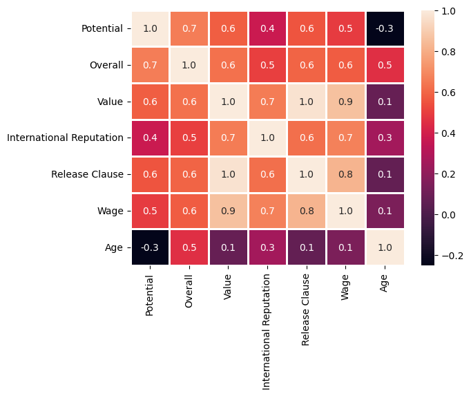

```python
sns.heatmap(data_corr, annot=True, fmt=".1f", linewidth=1)
plt.show()
```

- "Wage" has a Positive Correlation with Potential, Overall, Value, International Reputation, and Release Clause.
- Therefore, when the "Wage" is higher or lower, the other variables move in similar direction.
- "Wage" and "Age" indicate a minimal relationship.

### 18. Find the position in the pitch where the maximum number of players play and the position where the minimum number of players play? Display it using a plot.

```python
max_position = df['Position'].value_counts().sort_values(ascending=False).head(1)
print('Maximum Position of Players = ')
df_max_position = pd.DataFrame(max_position)
df_max_position.reset_index()
```

```
Maximum Position of Players =
```

|  | Position | count |
| --- | --- | --- |
| 0 | ST | 2212 |

```python
min_position = df['Position'].value_counts().sort_values(ascending=True).head(1)
print('Minimum Position of Players = ')
df_min_position = pd.DataFrame(min_position)
df_min_position.reset_index()
```

```
Minimum Position of Players =
```

|  | Position | count |
| --- | --- | --- |
| 0 | LF | 15 |

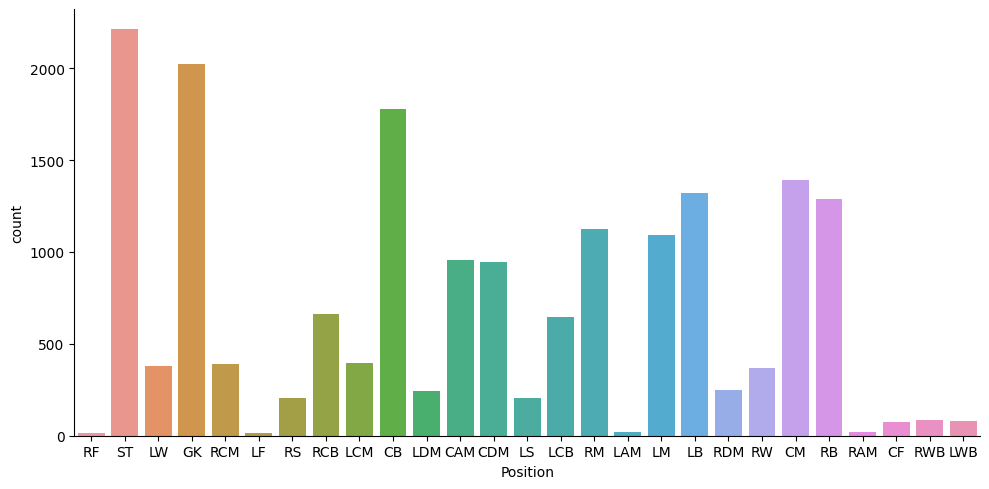

```python
sns.catplot(data=df, x="Position", kind="count", aspect=2)
plt.show()
```

### 19. How many players are from the club 'Juventus' and the wage is greater than 200K? Display all the information of such players.

```python
df[(df['Club'] == 'Juventus') & (df['Wage'] > 200000)].reset_index()
```

|  | index | ID | Name | Age | Nationality | Overall | Potential | Club | Value | Wage | Preferred Foot | International Reputation | Weak Foot | Skill Moves | Work Rate | Body Type | Position | Jersey Number | Joined | Contract Valid Until | Height | Weight | Crossing | Finishing | HeadingAccuracy | ShortPassing | Volleys | Dribbling | Curve | … |
| --- | --- | --- | --- | --- | --- | --- | --- | --- | --- | --- | --- | --- | --- | --- | --- | --- | --- | --- | --- | --- | --- | --- | --- | --- | --- | --- | --- | --- | --- | --- |
| 0 | 1 | 20801 | Cristiano Ronaldo | 33 | Portugal | 94 | 94 | Juventus | 77000000.0 | 405000.0 | Right | 5.0 | 4.0 | 5.0 | High/ Low | C. Ronaldo | ST | 7.0 | 2018 | 2022-01-01 | 6.17 | 183.0 | 84.0 | 94.0 | 89.0 | 81.0 | 87.0 | 88.0 | 81.0 | … |
| 1 | 15 | 211110 | P. Dybala | 24 | Argentina | 89 | 94 | Juventus | 89000000.0 | 205000.0 | Left | 3.0 | 3.0 | 4.0 | High/ Medium | Normal | LF | 21.0 | 2015 | 2022-01-01 | 5.83 | 165.0 | 82.0 | 84.0 | 68.0 | 87.0 | 88.0 | 92.0 | 88.0 | … |
| 2 | 24 | 138956 | G. Chiellini | 33 | Italy | 89 | 89 | Juventus | 27000000.0 | 215000.0 | Left | 4.0 | 3.0 | 2.0 | Medium/ High | Normal | LCB | 3.0 | 2005 | 2020-01-01 | 6.17 | 187.0 | 58.0 | 33.0 | 83.0 | 59.0 | 45.0 | 58.0 | 60.0 | … |

```python
df['Position'].unique()
```

```
array(['RF', 'ST', 'LW', 'GK', 'RCM', 'LF', 'RS', 'RCB', 'LCM', 'CB',
       'LDM', 'CAM', 'CDM', 'LS', 'LCB', 'RM', 'LAM', 'LM', 'LB', 'RDM',
       'RW', 'CM', 'RB', 'RAM', 'CF', 'RWB', 'LWB'], dtype=object)
```

```python
df['Position'].nunique()
```

```
27
```

```python
positions = df['Position'].unique()

for pos in positions:
    top_result = df[df['Position'] == pos].sort_values(by='Overall', ascending=False).head(5)
top_result.reset_index()
```

|  | index | ID | Name | Age | Nationality | Overall | Potential | Club | Value | Wage | Preferred Foot | International Reputation | Weak Foot | Skill Moves | Work Rate | Body Type | Position | Jersey Number | Joined | Contract Valid Until | Height | Weight | Crossing | Finishing | HeadingAccuracy | ShortPassing | Volleys | Dribbling | Curve | … |
| --- | --- | --- | --- | --- | --- | --- | --- | --- | --- | --- | --- | --- | --- | --- | --- | --- | --- | --- | --- | --- | --- | --- | --- | --- | --- | --- | --- | --- | --- | --- |
| 0 | 474 | 200536 | N. Schulz | 25 | Germany | 80 | 81 | TSG 1899 Hoffenheim | 14500000.0 | 37000.0 | Left | 1.0 | 2.0 | 3.0 | High/ Medium | Normal | LWB | 16.0 | 2017 | 2020-01-01 | 5.92 | 172.0 | 83.0 | 48.0 | 54.0 | 78.0 | 49.0 | 79.0 | 59.0 | … |
| 1 | 605 | 208334 | J. Hector | 28 | Germany | 79 | 79 | 1. FC Köln | 10000000.0 | 26000.0 | Left | 3.0 | 3.0 | 3.0 | Medium/ Medium | Normal | LWB | 3.0 | 2012 | 2023-01-01 | 6.08 | 165.0 | 79.0 | 55.0 | 71.0 | 78.0 | 51.0 | 74.0 | 65.0 | … |
| 2 | 581 | 223682 | Granell | 29 | Spain | 79 | 79 | Girona FC | 12000000.0 | 37000.0 | Left | 1.0 | 4.0 | 3.0 | Medium/ Medium | Normal | LWB | 6.0 | 2014 | 2021-01-01 | 5.75 | 154.0 | 73.0 | 74.0 | 55.0 | 83.0 | 56.0 | 76.0 | 80.0 | … |
| 3 | 601 | 210455 | Jonny | 24 | Spain | 79 | 83 | Wolverhampton Wanderers | 13500000.0 | 43000.0 | Right | 2.0 | 3.0 | 3.0 | High/ High | Normal | LWB | 19.0 | 2017 | 2019-06-30 | 5.58 | 154.0 | 77.0 | 34.0 | 70.0 | 73.0 | 44.0 | 73.0 | 60.0 | … |
| 4 | 787 | 214026 | J. Mojica | 25 | Colombia | 78 | 81 | Girona FC | 10500000.0 | 28000.0 | Left | 1.0 | 2.0 | 3.0 | High/ Medium | Lean | LWB | 3.0 | 2018 | 2022-01-01 | 6.08 | 161.0 | 79.0 | 62.0 | 55.0 | 78.0 | 43.0 | 78.0 | 74.0 | … |

### 21. What is the average wage one can expect to pay for the top 5 players in every position?

```python
positions = df['Position'].unique()
result = []

for pos in positions:
    top5 = df[df['Position'] == pos].sort_values(by='Overall', ascending=False).head(5)
    avg_wage = top5['Wage'].mean()
    result.append({'Position': pos, 'Average Wage': avg_wage})

result_df = pd.DataFrame(result)

result_df
```

|  | Position | Average Wage |
| --- | --- | --- |
| 0 | RF | 148000.0 |
| 1 | ST | 294000.0 |
| 2 | LW | 261000.0 |
| 3 | GK | 192800.0 |
| 4 | RCM | 240800.0 |
| 5 | LF | 121200.0 |
| 6 | RS | 132200.0 |
| 7 | RCB | 231000.0 |
| 8 | LCM | 184400.0 |
| 9 | CB | 139600.0 |
| 10 | LDM | 126600.0 |
| 11 | CAM | 174000.0 |
| 12 | CDM | 217000.0 |
| 13 | LS | 130200.0 |
| 14 | LCB | 162000.0 |
| 15 | RM | 131400.0 |
| 16 | LAM | 81600.0 |
| 17 | LM | 164600.0 |
| 18 | LB | 177200.0 |
| 19 | RDM | 105000.0 |
| 20 | RW | 202000.0 |
| 21 | CM | 130600.0 |
| 22 | RB | 155400.0 |
| 23 | RAM | 45400.0 |
| 24 | CF | 47400.0 |
| 25 | RWB | 44200.0 |
| 26 | LWB | 34200.0 |